# Average Pay of Seven Industries From 2013 to 2021

William Chao

November 2nd, 2021

## Purpose and Initial Set-Up

I wanted to analyze how the salaries have changed over time in San Francisco. For this analysis, I am only looking at the Hospital Administration, Human Services, Information Systems, Lab, Pharmacy & Med Techs, Legal & Court, Management, and Medical & Dental industries. I also wanted to know the population of each industry and how it has changed from 2013 to 2021.

I first set up my R-Studio by clearing the working environment and importing the necessary libraries. Then I import the CSV file from the working directory.

```r
rm(list=ls())
setwd('/Users/williamchao/Desktop/R Projects/Salary Analysis')
library(dplyr)
library(ggplot2)
compensation <- read.csv('Employee_Compensation.csv')
```

## Data Source and Overview of Data

I gathered data from DataSF, which is a non-profit organization that collects data on San Francisco. I first examined the dataset to ensure they are imported correctly. I then looked at the data structure to check if certain variables needed to be changed to make sense. Sure enough, I made changes to variables “Year,” “Job,” and “Job.Family,” as R read them as numeric and characters.

```r
glimpse(compensation)
```

```r
str(compensation)
```

```
## 'data.frame':    718449 obs. of  22 variables:
##  $ Organization.Group.Code: int  1 1 1 1 1 1 1 1 1 1 ...
##  $ Job.Family.Code        : chr  "1000" "1000" "1000" "1000" ...
##  $ Job.Code               : chr  "1021" "1023" "1031" "1054" ...
##  $ Year.Type              : chr  "Calendar" "Calendar" "Calendar" "Calendar" ...
##  $ Year                   : int  2013 2013 2013 2013 2013 2013 2013 2013 2013 2013 ...
##  $ Organization.Group     : chr  "Public Protection" "Public Protection" "Public Protection" "Public Protection" ...
##  $ Department.Code        : chr  "ADP" "ADP" "ADP" "ADP" ...
##  $ Department             : chr  "ADP Adult Probation" "ADP Adult Probation" "ADP Adult Probation" "ADP Adult Probation" ...
##  $ Union.Code             : int  21 21 21 21 21 21 21 21 21 21 ...
##  $ Union                  : chr  "Prof & Tech Engineers - Miscellaneous, Local 21" "Prof & Tech Engineers - Miscellaneous, Local 21" "Prof & Tech Engineers - Miscellaneous, Local 21" "Prof & Tech Engineers - Miscellaneous, Local 21" ...
##  $ Job.Family             : chr  "Information Systems" "Information Systems" "Information Systems" "Information Systems" ...
##  $ Job                    : chr  "IS Administrator 1" "IS Administrator 3" "IS Trainer-Assistant" "IS Business Analyst-Principal" ...
##  $ Employee.Identifier    : int  37730 26574 8148 27436 37730 36223 51426 26574 37983 16858 ...
##  $ Salaries               : num  57535 57678 63533 101275 5084 ...
##  $ Overtime               : num  0 0 0 0 0 0 0 0 0 0 ...
##  $ Other.Salaries         : num  0 0 0 -7059 0 ...
##  $ Total.Salary           : num  57535 57678 63533 94216 5084 ...
##  $ Retirement             : num  11253 10285 12496 19644 1084 ...
##  $ Health.and.Dental      : num  11961 7177 12918 12918 957 ...
##  $ Other.Benefits         : num  4533 4755 4703 7459 388 ...
##  $ Total.Benefits         : num  27747 22217 30117 40021 2428 ...
##  $ Total.Compensation     : num  85282 79895 93650 134237 7512 ...
```

## Manipulating Data Structure

I changed variables “Year,” “Job,” and “Job.Family” to factors and double-checked my data to make sure the changes took place.

```r
compensation$Year <- factor(compensation$Year)
compensation$Job <- factor(compensation$Job)
compensation$Job.Family <- factor(compensation$Job.Family)
str(compensation)
```

## Aggregate by Job Family

```r
Job_fam <- compensation %>%
  group_by(Job.Family, Year)%>%
  summarise_at(vars(Salaries), list(sum=sum, mean = mean))%>%
  mutate(n = sum/mean)%>%
  mutate(total_wealth = sum(sum))%>%
  arrange(desc(mean))
str(Job_fam)
```

## Data Cleaning

I filter the data only to inspect the industries I am interested in, which includes Hospital Administration, Human Services, Information Systems, Lab, Pharmacy & Med Techs, Legal & Court, Management, and Medical & Dental. I then renamed the columns appropriately. Once again, I double-check the data structure.

```r
Job_fam_sub <- Job_fam[Job_fam$Job.Family %in% c('Information Systems', 'Human Services',
                                                 'Management', 'SKilled Labor',
                                                 'Hospital Administration', 'Medical & Dental',
                                                 'Lab, Pharmacy & Med Techs', 'Legal & Court',
                                                 'Med Therapy & Auxilliary'),]

colnames(Job_fam_sub) <- c('Job_Category', 'Year', 'Total_Salaries_by_Job',
                           'Average_Salary', 'Number_of_Workers',
                           'Total_Wealth_in_Economy')
str(Job_fam_sub)
```

```
## grouped_df [63 × 6] (S3: grouped_df/tbl_df/tbl/data.frame)
##  $ Job_Category           : Factor w/ 59 levels "Administrative & Mgmt (Unrep)",..: 31 29 29 29 31 29 29 31 31 27 ...
##  $ Year                   : Factor w/ 9 levels "2013","2014",..: 9 9 8 7 8 6 5 6 7 9 ...
##  $ Total_Salaries_by_Job  : num [1:63] 5.05e+07 2.01e+08 3.89e+08 3.75e+08 9.18e+07 ...
##  $ Average_Salary         : num [1:63] 171848 159903 156987 152295 151460 ...
##  $ Number_of_Workers      : num [1:63] 294 1257 2481 2463 606 ...
##  $ Total_Wealth_in_Economy: num [1:63] 6.65e+08 2.78e+09 2.78e+09 2.78e+09 6.65e+08 ...
##  - attr(*, "groups")= tibble [7 × 2] (S3: tbl_df/tbl/data.frame)
##   ..$ Job_Category: Factor w/ 59 levels "Administrative & Mgmt (Unrep)",..: 21 23 24 26 27 29 31
##   ..$ .rows       : list<int> [1:7]
##   .. ..$ : int [1:9] 44 49 53 56 57 58 59 62 63
##   .. ..$ : int [1:9] 39 41 45 46 48 54 55 60 61
##   .. ..$ : int [1:9] 13 16 19 20 26 35 37 42 43
##   .. ..$ : int [1:9] 33 34 36 38 40 47 50 51 52
##   .. ..$ : int [1:9] 10 11 14 15 17 21 23 25 27
##   .. ..$ : int [1:9] 2 3 4 6 7 22 28 29 30
##   .. ..$ : int [1:9] 1 5 8 9 12 18 24 31 32
##   .. ..@ ptype: int(0)
##   ..- attr(*, ".drop")= logi TRUE
```

## Graph

Now that I have cleaned up the data only to include the industry I want. I started designing the graph using ggplot2.

```r
g1 <- ggplot(Job_fam_sub, aes(x = Year, y = Average_Salary, color = Job_Category))
g1 + geom_point(aes(size = Number_of_Workers)) + geom_line(aes(group = Job_Category), size = 1, alpha = 0.5) +
  labs(x = 'Year', y = 'Average Salary') + ggtitle('Average Salary Over Time') +
  theme(axis.text.x = element_text(color = 'Blue', size = 10),
        axis.text.y = element_text(color = 'DarkGreen', size = 10),
        axis.title.x = element_text(color = 'Blue', size = 12),
        axis.title.y = element_text(color = 'DarkGreen', size = 12),
        plot.title = element_text(size = 15, hjust = 0.5),
        legend.title = element_text(size = 10))
```

## Analysis

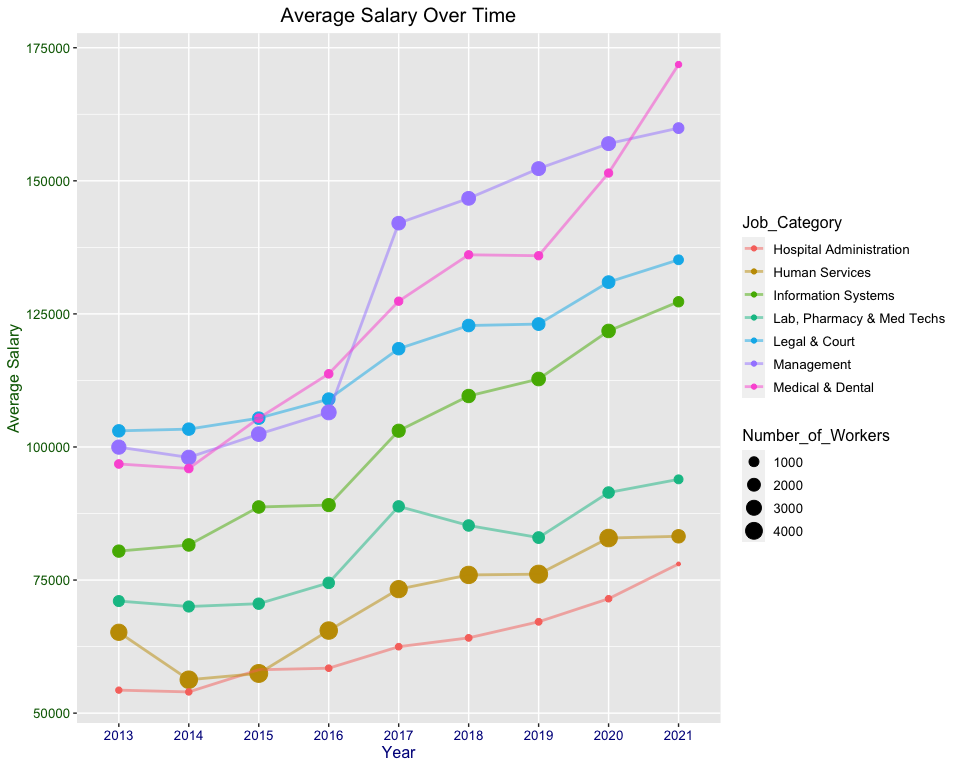

```r
g1 <- ggplot(Job_fam_sub, aes(x = Year, y = Average_Salary, color = Job_Category))
g1 + geom_point(aes(size = Number_of_Workers)) + geom_line(aes(group = Job_Category), size = 1, alpha = 0.5) +
  labs(x = 'Year', y = 'Average Salary') + ggtitle('Average Salary Over Time') +
  theme(axis.text.x = element_text(color = 'DarkBlue', size = 10),
        axis.text.y = element_text(color = 'DarkGreen', size = 10),
        axis.title.x = element_text(color = 'DarkBlue', size = 12),
        axis.title.y = element_text(color = 'DarkGreen', size = 12),
        plot.title = element_text(size = 15, hjust = 0.5),
        legend.title = element_text(size = 12),
        legend.text = element_text(size = 10))
```

It is also interesting to see how the number of workers in each industry fluctuates. For example, the Hospital Administration industry already has the lowest number of workers, yet it still saw a noticeable decrease in its workforce in 2021. It is essential to note that this decrease in the workforce is not unique to the Hospital Administration industry, as the overall workforce in these industries has decreased. The pandemic is likely the culprit behind the drop in the working population, as workers experienced higher burnout than they usually do. I have separated the industries and added their workforce number into the graph below.

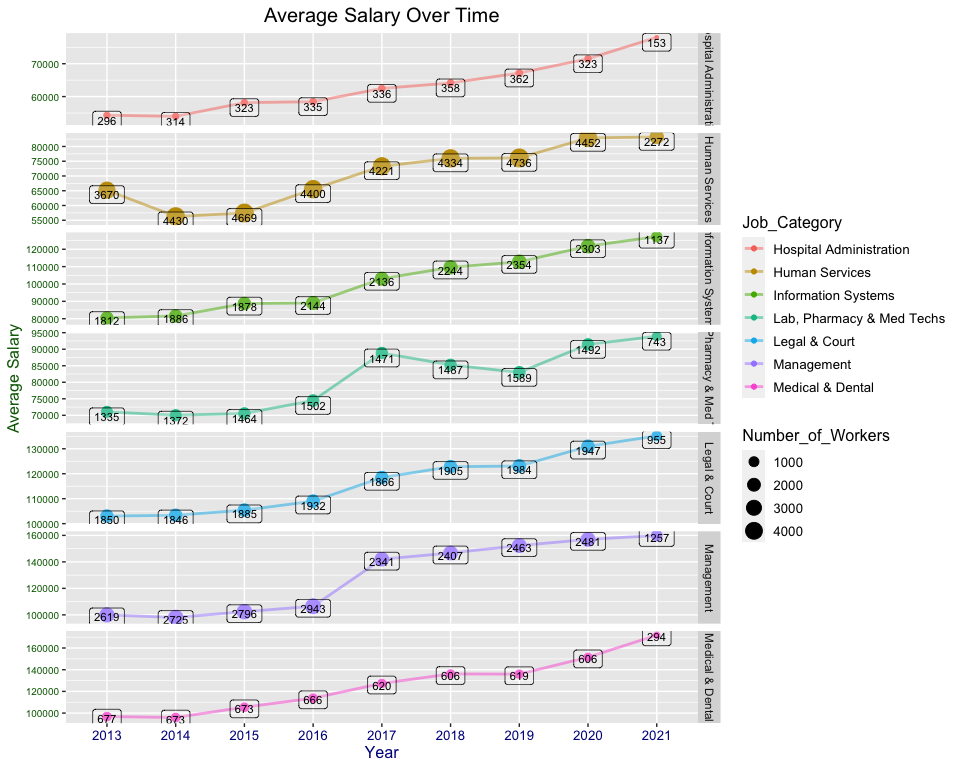